# Régression linéaire

Python works with packages. A large number of packages can be dowloaded all together in the Anaconda environment. Start downloading here (version >3) https://www.anaconda.com/download/ Anaconda comes with

- Spyder, a GUI for python
- Jupyter Notebook, how to create great documents

Enjoy!

Bee careful :

- Python is sensible to spaces in the beginning of lines,
- Python is sensible to number type : $3$ and $3.$ are totally different: *integer* and *float* types.

```python
import warnings
warnings.filterwarnings('ignore')

import numpy as np
import numpy.random as npr
import matplotlib.pyplot as plt
import pandas as pd
```

# Les données

Le fichier **Supra_data_s.txt** contient les données relevées lors d’une étude prospective (*SUPRA - Supervision of the PRogression of Atherosclerosis in HIV-1 infected patients*) parmi des participants de la cohorte Aquitaine. L’étude portait sur l’évaluation des facteurs de risques associés aux maladies cardiovasculaires chez les patients infectés par le VIH, en utilisant le marqueur *IMT - intima media thickness of the carotid arteries* (colonne **mesure**). L’étude comportait le relevé d’autres marqueurs connus comme étant des facteurs de risques des maladies cardiovasculaires : **sexe** (SEXE = 1 si homme, 2 si femme), **age** (AGE en années), **taille** (en cm), **poids** (en kg), **habitudes liées au sport** (0=non sportif, 1=sportif), **tabac et prise d’alcool** (0=consommation nulle, 1=consommation occasionnelle, 2=consommation régulière).

```python
data = np.loadtxt("Supra_data_s.txt",skiprows=1)
header = ["SEXE","AGE","taille","poids","tabac","SPORT","mesure","alcool"]
print(data[0:10,:])
```

```
[[  1.    33.   170.    70.     1.     0.     0.52   1.  ]
 [  2.    33.   177.    67.     2.     0.     0.42   1.  ]
 [  2.    53.   164.    63.     1.     0.     0.65   0.  ]
 [  2.    42.   169.    76.     1.     1.     0.48   1.  ]
 [  2.    53.   152.    54.     0.     0.     0.45   1.  ]
 [  2.    50.   162.    53.     2.     0.     0.49   1.  ]
 [  1.    22.   181.    72.     0.     1.     0.42   1.  ]
 [  2.    26.   162.    61.     1.     1.     0.45   1.  ]
 [  1.    50.   170.    80.     0.     0.     0.65   2.  ]
 [  2.    47.   178.    73.     0.     0.     0.52   1.  ]]
```

### Creation du BMI

Créer la variable **BMI** *Indice de Masse Corporelle* telle que $$ BMI=\frac{Poids}{Taille^2}, $$ et l'ajouter au dataset.

```python
bmi = data[:,3:4]/(data[:,2:3]/100)**2
data = np.concatenate((data,bmi),axis=1)
header = header + ["bmi"]
print(data.shape)
```

```
(110, 9)
```

# La régression linéaire

**QUESTION** Visualiser :

- **IMT** en fonction de **BMI**
- **IMT** en fonction de **age**
- **IMT** en fonction de **taille**
- **IMT** en fonction de **poids**

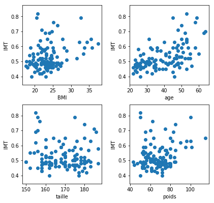

```python
plt.figure(1)
plt.subplot(221)
plt.scatter(data[:,8],data[:,6])
plt.xlabel("BMI")
plt.ylabel("IMT")

plt.subplot(222)
plt.scatter(data[:,1],data[:,6])
plt.xlabel("age")
plt.ylabel("IMT")

plt.subplot(223)
plt.scatter(data[:,2],data[:,6])
plt.xlabel("taille")
plt.ylabel("IMT")

plt.subplot(224)
plt.scatter(data[:,3],data[:,6])
plt.xlabel("poids")
plt.ylabel("IMT")

plt.subplots_adjust(top=0.92, bottom=-0.3, left=0.10, right=0.95, hspace=0.25,wspace=0.35)
```

**QESTION** Quel est selon vous la variable qui permette le mieux de prédire, avec un **modèle linéaire** la variable **IMT** ?

**QUESTION** Pour chacun des couples vu précédemment, calculer le coefficient de corrélation de Pearson. Et commenter en fonction de ce qui a été vu dans la question précédente.

```python
for i in [8,1,2,3]:
    print(np.corrcoef(data[:,6],data[:,i])[0,1])
```

```
0.30717287224763695
0.552366859681787
-0.06865902433560454
0.22952003414114933
```

**QUESTION** Utiliser la fonction *OLS* de la librairie *statsmodels.api* afin d'estimer le modèle de régression prédisant l'**IMT** en fonction des autres variables du problème. Le modèles sera noté *model*, la matrice des coefficients de régression sera notée $B$ et l'intercept (*=ordonnée à l'origine*) $B_0$. On fera attention à inclure l'intercept dans le modèle.

```python
import statsmodels.api as sm

# Delete 6th column of data and put it in the matrix X
# sm.add_constant permits to include the computation of the intercept in the model :) do not forget it!
X = sm.add_constant(np.delete(data,6,1))
Y = data[:,6:7]

model = sm.OLS(Y, X).fit()

B_0 = model.params[0]
B = np.delete(np.array([model.params]).T,0,0)
```

**QUESTION** Observer le détail du modèle linéaire construit et interprêter les différentes **p-values**.

```python
print(model.summary())
```

```
                            OLS Regression Results
==============================================================================
Dep. Variable:                      y   R-squared:                       0.398
Model:                            OLS   Adj. R-squared:                  0.350
Method:                 Least Squares   F-statistic:                     8.337
Date:                Wed, 14 Nov 2018   Prob (F-statistic):           1.26e-08
Time:                        14:04:36   Log-Likelihood:                 141.35
No. Observations:                 110   AIC:                            -264.7
Df Residuals:                     101   BIC:                            -240.4
Df Model:                           8
Covariance Type:            nonrobust
==============================================================================
                 coef    std err          t      P>|t|      [0.025      0.975]
------------------------------------------------------------------------------
const          1.8571      0.794      2.339      0.021       0.282       3.432
x1             0.0078      0.019      0.420      0.675      -0.029       0.045
x2             0.0041      0.001      5.571      0.000       0.003       0.006
x3            -0.0097      0.005     -2.049      0.043      -0.019      -0.000
x4             0.0137      0.006      2.317      0.023       0.002       0.025
x5             0.0040      0.009      0.439      0.662      -0.014       0.022
x6            -0.0007      0.014     -0.052      0.958      -0.028       0.027
x7             0.0060      0.012      0.481      0.631      -0.019       0.031
x8            -0.0334      0.016     -2.033      0.045      -0.066      -0.001
==============================================================================
Omnibus:                       13.948   Durbin-Watson:                   1.962
Prob(Omnibus):                  0.001   Jarque-Bera (JB):               17.717
Skew:                           0.681   Prob(JB):                     0.000142
Kurtosis:                       4.418   Cond. No.                     2.24e+04
==============================================================================

Warnings:
[1] Standard Errors assume that the covariance matrix of the errors is correctly specified.
[2] The condition number is large, 2.24e+04. This might indicate that there are
strong multicollinearity or other numerical problems.
```

**QUESTION** Quelles sont les variables significatives ?

Ce sont :

- `const` soit l'intercept
- `x2` soit **AGE**
- `x3` soit **taille**
- `x4` soit **poids**
- `x8` soit **IMC**

**QUESTION** Créer un nouveau modèle avec ces variables et observer les éventuelles modifications.

```python
X = sm.add_constant(data[:,[1,2,3,8]])
Y = data[:,6:7]

model_sparse = sm.OLS(Y, X).fit()

B_0 = model_sparse.params[0]
B = np.delete(np.array([model_sparse.params]).T,0,0)

print(model_sparse.summary())
```

```
                            OLS Regression Results
==============================================================================
Dep. Variable:                      y   R-squared:                       0.395
Model:                            OLS   Adj. R-squared:                  0.371
Method:                 Least Squares   F-statistic:                     17.10
Date:                Wed, 14 Nov 2018   Prob (F-statistic):           7.89e-11
Time:                        14:14:07   Log-Likelihood:                 141.05
No. Observations:                 110   AIC:                            -272.1
Df Residuals:                     105   BIC:                            -258.6
Df Model:                           4
Covariance Type:            nonrobust
==============================================================================
                 coef    std err          t      P>|t|      [0.025      0.975]
------------------------------------------------------------------------------
const          1.8393      0.771      2.386      0.019       0.311       3.368
x1             0.0043      0.001      6.676      0.000       0.003       0.006
x2            -0.0095      0.005     -2.068      0.041      -0.019      -0.000
x3             0.0133      0.006      2.344      0.021       0.002       0.025
x4            -0.0325      0.016     -2.046      0.043      -0.064      -0.001
==============================================================================
Omnibus:                       12.679   Durbin-Watson:                   1.958
Prob(Omnibus):                  0.002   Jarque-Bera (JB):               15.569
Skew:                           0.640   Prob(JB):                     0.000416
Kurtosis:                       4.326   Cond. No.                     2.21e+04
==============================================================================

Warnings:
[1] Standard Errors assume that the covariance matrix of the errors is correctly specified.
[2] The condition number is large, 2.21e+04. This might indicate that there are
strong multicollinearity or other numerical problems.
```

**QUESTION** Représenter les valeurs prédites en fonction des valeurs réelles.

```
Text(0,0.5,'IMT prédit')
```

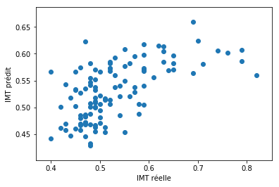

```python
plt.scatter(Y,model_sparse.predict(X))
plt.xlabel("IMT réelle")
plt.ylabel("IMT prédit")
```

**QUESTION** Tracer les **résidus** en fonction des valeurs estimées et juger de l'hypothèse d'homoscédasticité. Qu'observe-t-on ?

```
Text(0,0.5,'Résidus')
```

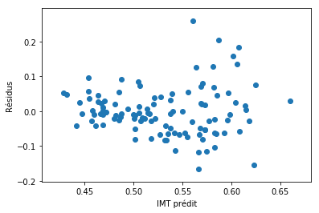

```python
plt.scatter(model_sparse.predict(X),Y.T-model_sparse.predict(X))
plt.xlabel("IMT prédit")
plt.ylabel("Résidus")
```

**QUESTIONS FINALES**

- Lequel des 2 modèles construits est-il le plus précis ?
- Lequel le clinicien va-t-il privilégier ?
- Lequel a le plus d'intérêt ?

**QUESTION EN PLUS**

Si le temps le permet regarder les résidus en fonction de toutes les variables explicatives et dire si' l'éventuelle hétéroscédasticité peut venir de telle ou telle variable.